# HW1 - Data Scraping & Taste of Data Analysis

#### Data Science in Korea University

#### COSE471, Spring 2015

#### Due : 3/30 (MON) 11:59 PM

## Fetching population data from Wikipedia

In this example we will fetch data about countries and their population from Wikipedia.

http://en.wikipedia.org/wiki/List_of_countries_by_past_and_future_population has several tables for individual countries, subcontinents as well as different years.

### We will go through the following steps:

- fetching html with embedded data
- parsing html to extract the data
- collecting the data in a panda dataframe
- displaying the data

To give you some starting points for your homework, we will also show the different sub-steps that can be taken to reach the presented solution.

```python
# special IPython command to prepare the notebook for matplotlib
%matplotlib inline

from collections import defaultdict

import pandas as pd
import matplotlib.pyplot as plt
import requests
from pattern import web
from BeautifulSoup import BeautifulSoup
```

## 0. Fetching the Wikipedia site

##### Use requests library

```python
url = 'http://en.wikipedia.org/wiki/List_of_countries_by_past_and_future_population'

# write your code here
website_html = requests.get(url).text
#print website_html
```

[output not shown]

[output cut: 14917 more lines]

[output not shown]

## 1. Parsing html data

Data that we are going to use is “tables” titled below:

- Country and territory breakdown by past or historical (and consolidated) population, from 1950 to 1980
- Country and territory breakdown by past or historical (and consolidated) population, from 1985 to 2015
- Country and territory breakdown by past or historical (and consolidated) population, from 2020 to 2050

##### Use either Pattern or BeautifulSoup

```python
def get_population_html_tables(html):
    """
    Parse html and

    return: html tables of wikipedia population data.
    """

    dom = web.Element(html)    #pattern.web method Element

    #step1: look at html source!"

    #step2: get all tables"
    #tbls = dom('table')
    #step3: get all tables we care about"
    tbls = dom.by_class('sortable wikitable') # return a list of Elements
    return tbls

tables = get_population_html_tables(website_html) # list of Elements with
                                                # sortable wikitable class
print "table length: %d" % len(tables)
for t in tables:
    print t.attributes # Element.attributes -> dict of attributes
    # write your code here
```

```
table length: 6
{u'style': u'text-align: right', u'class': u'sortable wikitable'}
{u'style': u'text-align: right', u'class': u'sortable wikitable'}
{u'style': u'text-align: right', u'class': u'sortable wikitable'}
{u'style': u'text-align: right', u'class': u'sortable wikitable'}
{u'style': u'text-align: right', u'class': u'sortable wikitable'}
{u'style': u'text-align: right', u'class': u'sortable wikitable'}
```

## 2. Extracting data and filling it into a dictionary(Python data stucture)

"""Extract population data for countries from all tables and store it in dictionary."""

```python
def table_type(tbl):
    '''
    tbl: dom
    return: table type
    '''
    # 1st try
    # print tbl('th')

    # 2nd try
    #for th in tbl('th'):
    #    print th.content
    #return 'table'

    # 3rd try
    return tbl('th')[0].content



## group the tables by type

tables_by_type = defaultdict(list) # == defaultdict(<type 'list'>, {})
# class defaultdict
# defaultdicts have a default value that is inserted
# when a new key is accessed

for tbl in tables:
    tables_by_type[table_type(tbl)].append(tbl)
    ## without defaultdict method - 1 ##
    #typ = table_type(tbl)
    #if typ in tables_by_type:
    #    tables_by_type[typ].append(tbl)
    #else:
    #    tables_by_type[typ] = [tbl]

    ## without defaultdict method - 2 ##
    #typ = table_type(tbl)
    #if typ not in tables_by_type:
        #tables_by_type[typ] = list() # []
    #tables_by_type[typ].append(tbl)

print tables_by_type
```

```
defaultdict(<type 'list'>, {u'Country or territory': [Element(tag=u'table'), Element(tag=u'table'), Element(tag=u'table')], u'(Sub)continent': [Element(tag=u'table'), Element(tag=u'table'), Element(tag=u'table')]})
```

```python
# write your code here
def get_countries_population(tables):
    """
    tables: list of dom Elements
    Extract population data for countries from all tables and
    store it in dictionary.
    """
    result = defaultdict(dict)
        # 1. step: try to extract data for a single table
    for tbl in tables:
        #tbl = tables[0]    # dom
        headers = tbl('tr')    # list
        first_header = headers[0]   # dom
        th_s = first_header('th')    # list

        years = [int(val.content) for val in th_s if val.content.isnumeric()]
        year_indices = [idx for idx, val in enumerate(th_s) if val.content.isnumeric()]
        print years
        print year_indices

        # 2. step: iterate over all tables, extract headings and actual data and combine data into single dict
        rows = tbl('tr')[1:]
        for row in rows:
            tds = row('td')    # list of td doms
            country_name = tds[0]('a')[0].content
            population_by_year = [int(tds[colidx].content.replace(',',''))
                                  for colidx in year_indices]
            subdict = dict(zip(years, population_by_year))    # dict, key = years, vals = population
            result[country_name].update(subdict)
    return result

result = get_countries_population(tables_by_type['Country or territory'])
print len(result), "Countries extracted"
print result['Canada']
print hash(1985), hash(2050)
```

```
[1950, 1955, 1960, 1965, 1970, 1975, 1980]
[1, 2, 4, 6, 8, 10, 12]
[1985, 1990, 1995, 2000, 2005, 2010, 2015]
[1, 3, 5, 7, 9, 11, 13]
[2020, 2025, 2030, 2035, 2040, 2045, 2050]
[1, 3, 5, 7, 9, 11, 13]
227 Countries extracted
{1985: 25942, 2050: 41136, 1955: 16050, 2020: 36387, 1990: 27791, 1960: 18267, 2025: 37559, 1995: 29691, 1965: 20071, 2030: 38565, 2000: 31100, 1970: 21750, 2035: 39396, 2005: 32386, 1975: 23209, 2040: 40070, 2010: 33760, 1980: 24593, 2045: 40635, 1950: 14011, 2015: 35100}
1985 2050
```

## 3. Creating a dataframe(Python data structure) from a dictionary

```python
# create dataframe
# Use the following code
df = pd.DataFrame.from_dict(result, orient = 'index' ) # default 'columns'

# sort based on year
df.sort(axis=1,inplace=True)
print df
```

```
                                1950    1955    1960    1965    1970    1975  \
Afghanistan                     8150    8891    9829   10998   12431   14132
Albania                         1227    1392    1623    1884    2157    2401
Algeria                         8893    9842   10909   11963   13932   16140
American Samoa                    19      20      20      25      27      30
Andorra                            6       6       8      14      20      27
Angola                          4118    4423    4797    5135    5606    6050
Anguilla                           5       5       6       6       6       6
Antigua and Barbuda               46      51      55      59      66      68
Argentina                      17150   18928   20616   22283   23962   26082
Armenia                         1355    1565    1869    2206    2520    2834
Aruba                             50      54      57      59      59      59
Australia                       8267    9277   10361   11439   12660   13771
Austria                         6935    6947    7047    7271    7467    7579
Azerbaijan                      2885    3314    3882    4567    5169    5696
Bahamas                           70      87     112     139     170     189
Bahrain                          115     130     157     191     220     259
Bangladesh                     45646   49588   54593   60284   67331   76153
Barbados                         211     227     232     235     239     247
Belarus                         7722    7781    8168    8591    9027    9360
Belgium                         8639    8868    9119    9448    9638    9795
Belize                            66      77      92     107     122     136
Benin                           1673    1846    2055    2311    2620    2996
Bermuda                           39      41      44      49      53      54
Bhutan                           164     186     212     254     309     373
Bolivia                         2766    3074    3434    3853    4346    4914
Bosnia and Herzegovina          2662    2974    3240    3493    3703    3980
Botswana                         430     461     497     538     584     705
Brazil                         53443   61774   71695   83093   95684  108879
British Virgin Islands             6       7       7       8      10      11
Brunei                            45      61      83     102     128     156
...                              ...     ...     ...     ...     ...     ...
Taiwan                          7981    9486   11209   12978   14598   16122
Tajikistan                      1530    1781    2081    2511    2939    3449
Tanzania                        7935    8971   10260   11870   13807   16148
Thailand                       20042   23451   27513   32062   37091   42272
Timor-Leste                      436     472     509     553     598     677
Togo                            1172    1298    1456    1648    1964    2267
Tonga                             46      54      64      74      83      89
Trinidad and Tobago              632     721     841     939     955    1007
```

[output cut: 198 more lines]

```
United States                 393856  408012  422554
United States Virgin Islands      99      96      92
Uruguay                         3500    3503    3495
Uzbekistan                     34278   34768   35116
Vanuatu                          296     305     312
Venezuela                      37942   39173   40256
Vietnam                       109601  110717  111174
Wallis and Futuna                 16      16      16
West Bank                       4041    4225    4376
Western Sahara                   997    1086    1173
Yemen                          40901   43436   45781
Zambia                         30121   34040   38372
Zimbabwe                       21839   23491   25198

[227 rows x 21 columns]
```

## 3-1. Some data accessing functions for a panda dataframe

```python
subtable = df.iloc[0:2, 0:2]
print "subtable"
print subtable
print ""

column = df[1955]
print "column"
print column
print ""

row = df.ix[0] #row 0
print "row"
print row
print ""

rows = df.ix[:2] #rows 0,1
print "rows"
print rows
print ""

element = df.ix[0,1955] #element
print "element"
print element
print ""

# max along column
print "max"
print df[1950].max()
print ""

# axes
print "axes"
print df.axes
print ""

row = df.ix[0]
print "row info"
print row.name
print row.index
print ""

countries =  df.index
print "countries"
print countries
print ""

print "Austria"
print df.ix['Austria']
```

```
subtable
             1950  1955
Afghanistan  8150  8891
Albania      1227  1392

column
Afghanistan             8891
Albania                 1392
Algeria                 9842
American Samoa            20
Andorra                    6
Angola                  4423
Anguilla                   5
Antigua and Barbuda       51
Argentina              18928
Armenia                 1565
Aruba                     54
Australia               9277
Austria                 6947
Azerbaijan              3314
Bahamas                   87
...
United Arab Emirates                83
United Kingdom                   50946
United States                   165069
United States Virgin Islands        28
Uruguay                           2353
Uzbekistan                        7232
Vanuatu                             59
Venezuela                         6170
Vietnam                          27738
Wallis and Futuna                    7
West Bank                          788
Western Sahara                      16
Yemen                             5265
Zambia                            2869
Zimbabwe                          3409
Name: 1955, Length: 227, dtype: int64

row
```

[output cut: 62 more lines]

```
1985    7560
1990    7723
1995    8047
2000    8113
2005    8185
2010    8214
2015    8224
2020    8220
2025    8190
2030    8120
2035    8009
2040    7867
2045    7702
2050    7521
Name: Austria, dtype: int64
```

## 4-1. Plotting population from 1950 to 2050 of 5 countries

### South Korea, China, Japan, India, U.S.

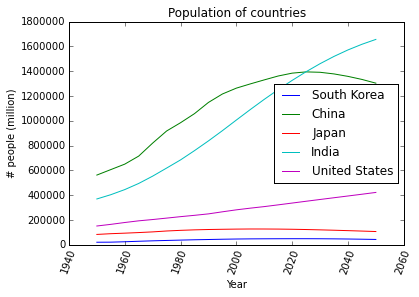

```python
plotCountries = ['South Korea', 'China', 'Japan', 'India', 'United States']

for country in plotCountries:
    row = df.ix[country]
    plt.plot(row.index, row, label=row.name)

plt.ylim(ymin=0) # start y axis at 0

plt.xticks(rotation=70)    # x values tilted
plt.legend(loc='best')    # line label
plt.xlabel("Year")
plt.ylabel("# people (million)")
plt.title("Population of countries")
```

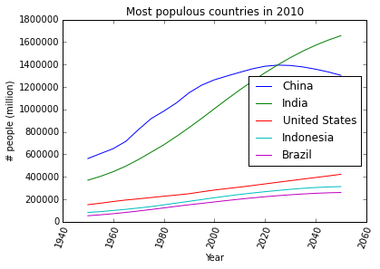

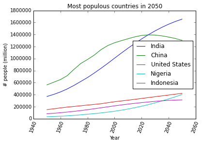

```python
def plot_populous(df, year):
    # sort table depending on data value in year column
    df_by_year = df.sort(year, ascending=False)

    plt.figure()
    for i in range(5):
        row = df_by_year.ix[i]
        plt.plot(row.index, row, label=row.name)

    plt.ylim(ymin=0) # start y axis at 0

    plt.xticks(rotation=70)    # x values tilted
    plt.legend(loc='best')    # line label
    plt.xlabel("Year")
    plt.ylabel("# people (million)")
    plt.title("Most populous countries in %d" % year)

plot_populous(df, 2010)
plot_populous(df, 2050)
```

## 5-1. Your Code for Analysis(1/3): 한국의 인구 증감/증감율 예측 (2010-2050)

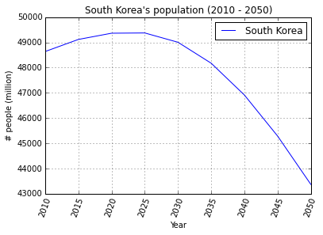

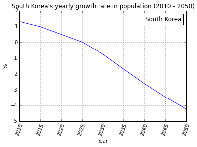

```python
## 1. organize data

# yearly growth = (year(n) - year(n-5))/year(n-5)
# year(n)
skorea_2010_2050 = df[[2010,2015,2020,2025,2030,2035,2040,2045,2050]].ix['South Korea']

# year(n-5)
skorea_2005_2045 = df[[2005,2010,2015,2020,2025,2030,2035,2040,2045]].ix['South Korea']
skorea_2005_2045 = skorea_2005_2045.rename(index = {i:i+5 for i in skorea_2005_2045.index})
# year(n) - year(n-5)
skorea_difference = (skorea_2010_2050 - skorea_2005_2045)

# (year(n) - year(n-5))/year(n-5)
skorea_growthrate = skorea_difference / skorea_2005_2045 * 100

## 2. population graph
plt.figure()
plt.plot(skorea_2010_2050.index, skorea_2010_2050, label = skorea_2010_2050.name)

plt.xticks(rotation=70)    # x values tilted
plt.legend(loc='best')    # line label
plt.xlabel("Year")
plt.ylabel("# people (million)")
plt.title("South Korea's population (2010 - 2050)")
plt.grid()


## 3. growth rate graph
plt.figure()
plt.plot(skorea_growthrate.index, skorea_growthrate, label = skorea_growthrate.name)

plt.xticks(rotation=70)    # x values tilted
plt.legend(loc='best')    # line label
plt.xlabel("Year")
plt.ylabel("%")
plt.title("South Korea's yearly growth rate in population (2010 - 2050)")
plt.grid()
```

## 5-2. Your Code for Analysis(2/3): 전세계 인구 증감율 히스토그램 (2010년 대비 2050년 증감율) & 최고 인구 증감율 국가 인구 그래프

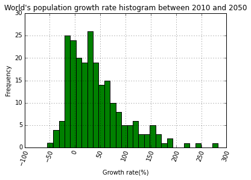

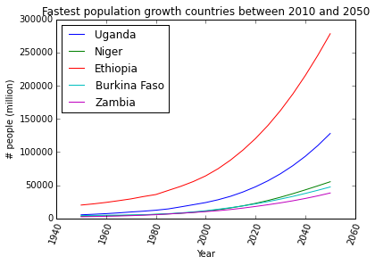

```python
## 1. organize data

growth_unsorted = (df[2050]-df[2010])/df[2010]*100
growth_unsorted_df = pd.DataFrame(growth_unsorted, columns = ['growth rate between 2010 and 2050'])
growth_sorted = growth_unsorted_df.sort('growth rate between 2010 and 2050', ascending = False)


## 2. histogram
plt.hist(growth_unsorted,30,color='green',alpha=1)
plt.xticks(rotation=70)    # x values tilted
plt.legend(loc='best')    # line label
plt.xlabel("Growth rate(%)")
plt.ylabel("Frequency")
plt.title("World's population growth rate histogram between 2010 and 2050")
plt.grid()

## 3. top 5 growth rate countries
fast_countries = growth_sorted.index[:5]

plt.figure()
for c in fast_countries:
    row = df.ix[c]
    plt.plot(row.index, row, label=row.name)


plt.ylim(ymin=0) # start y axis at 0

plt.xticks(rotation=70)    # x values tilted
plt.legend(loc='best')    # line label
plt.xlabel("Year")
plt.ylabel("# people (million)")
plt.title("Fastest population growth countries between 2010 and 2050")
```

## 5-3. Your Code for Analysis(3/3): OECD 인구 증감율 막대 그래프 (2010년 대비 2050년 증감율)

```python
!pip install titlecase
from titlecase import titlecase
```

```
Cleaning up...
```

```
                growth rate between 2010 and 2050
Luxembourg                              44.779116
United States                           37.067360
Ireland                                 37.010599
Australia                               34.843837
Mexico                                  31.510016
Turkey                                  29.755540
New Zealand                             22.271872
Canada                                  21.848341
Chile                                   15.770930
United Kingdom                          14.123949
Iceland                                 13.592233
Spain                                   12.869307
Netherlands                              8.042718
France                                   7.719862
Norway                                   6.201882
Italy                                    1.097960
Denmark                                  1.069616
Sweden                                   0.121225
Switzerland                             -4.289650
Belgium                                 -5.180850
Greece                                  -6.641860
Portugal                                -7.479508
Finland                                 -8.277831
Austria                                 -8.436815
Slovakia                                -9.616088
South Korea                            -10.829427
Germany                                -12.373230
Hungary                                -15.032026
Japan                                  -15.965794
Czech Republic                         -16.290923
Poland                                 -16.584339
Slovenia                               -20.269596
Estonia                                -33.230054
```

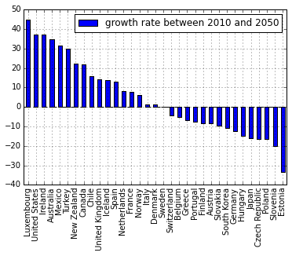

```python
## 1.1 get oecd name list
url_OECD = 'http://oecd.org/about/membersandpartners/list-oecd-member-countries.htm'

def get_OECD_list(url):
    content = requests.get(url).text

    dom = web.Element(content)    #pattern.web method Element
    table = dom("table")[1]('td')

    countries = []
    for i in table:
        if i.by_class("&amp;amp;quot;more&amp;amp;quot;") != []:
            countries.append(i[0])

    names = []
    for c in countries[:-1]:
        names.append(titlecase(str(c.content).lower()))

    return names

## 1.2 make some adjustments on differences in names
oecd = get_OECD_list(url_OECD)
oecd.remove('Korea')
oecd.append('South Korea')
oecd.remove('Slovak Republic')
oecd.append('Slovakia')

## 2. from dataframe, extract records of oecd countries
growth_oecd = growth_unsorted_df.loc[[c for c in oecd],:].sort('growth rate between 2010 and 2050', ascending=False)
print growth_oecd


## 3. bar chart on grwoth rates
growth_oecd.plot(kind='bar')
```

## 5-4. Your Analysis Report (Either Korean or English)

# 1. 한국의 인구 증감/증감율 예측 (2010 - 2050)

```
- 인구 증감율 그래프 조사 방법: 5년 단위로 인구 증감율 측정
예) 2015년 인구 증감율(%) = {(2015년 인구 증감)/2010년 인구} * 100 = {(2015년 인구 - 2010년 인구)/2010년 인구} * 100

- 한국의 인구는 2025년을 기점으로 하락하며, 그 하락률이 점차 증가하는 양상을 보인다. 한국 인구 감소의 원인은 저출산과 고령화다. 여성의 사회 진출과 양육비용의 지속적 증가로 자녀를 적게 낳거나 낳지 않는 사람이 늘어나고, 베이비붐 세대의 고령화로 인해 고령 인구 비율이 점점 높아지고 있기 때문이다.

참고: http://magazine.hankyung.com/business/apps/news?popup=0&nid=01&nkey=2014011600946000211&mode=sub_view
```

# 2. 전세계 인구 증감율 히스토그램 (2010년 대비 2050년 증감율) & 최고 인구 증감율 국가 인구 그래프

```
- 히스토그램 조사 방법: 인구 증감율(%) = {(2050년 인구 - 2010년 인구)/2010년 인구} * 100

- 전세계 국가들의 2010년 대비 2050년 인구 증감율로 히스토그램을 만들었을 때 대략 5 개의 아웃라이어를 발견할 수 있다. 인구 증가율이 가장 가파른 이들 다섯 개 국가는 그 다음 그래프에서 보듯이, Uganda, Niger, Ethiopia, Burkina Faso, Zambia로 모두 아프리카 국가들이다. 이처럼 아프리카 국가들의 인구증가율이 가장 가파른 까닭은 지속적으로 높은 출산율과 성공적인 에이즈 퇴치 노력 때문이다. 대부분의 아프리카 국가의 출산율은 5명 정도이며, Niger의 경우에는 무려 7명에 이른다. 또한 에이즈 퇴치 노력으로 사망자수가 준 것도 영향을 끼쳤다.

참고: http://www.economist.com/blogs/graphicdetail/2013/06/daily-chart-10
     http://www.hani.co.kr/arti/society/society_general/656619.html
```

# 3. OECD 인구 증감율 막대 그래프 (2010년 대비 2050년 증감율)

```
- 인구 증감율 막대 그래프 조사 방법: 인구 증감율(%) = {(2050년 인구 - 2010년 인구)/2010년 인구} * 100

- 룩셈부르크의 인구 증감율이 OECD 국가 중 가장 높은 것으로 나타나는데, 룩셈부르크는 인구가 작아 적극적인 이민 정책을 실시하기 때문으로 볼 수 있다. 룩셈부르크는 이민자에게도 공직을 개방하고 투표권을 부여한다. 현재 35퍼센트의 인구가 이민자로 이루어져 있다. 이러한 적극적인 이민 정책은 룩셈부르크의 미래 인구 증가에 긍정적 영향을 미치는 것으로 보인다.

참고: http://www.nationsencyclopedia.com/economies/Europe/Luxembourg.html
```